# Task 1: Treatment Effect Heterogeneity

Visual Assessment

## Setup

```r
library(tidyverse)
library(glue)
library(patchwork)
library(knitr)
library(here)
library(fs)

source(here::here("R", "task1_helpers.R"))

results_dir <- here::here("results")
data_dir <- here::here("ressources", "Datasets", "Datasets", "Blinded_data_sets")

csv_files <- get_csv_file_names(data_dir)

#csv_files <- csv_files[1]

dataset_records <- build_task1_dataset_records(
  csv_files = csv_files,
  n_bins = params$n_bins,
  min_arm_n = params$min_arm_n
)
```

## Scope of this document

This report is restricted to **visual exploration for Task 1**.

It is used to inspect whether treatment effect heterogeneity appears visually plausible within a dataset.

It does **not** perform:

- final variable selection
- patient-level subgroup assignment
- final dataset-level automatic yes or no decisions

Numeric prioritisation is used only to sort and visually mark univariate plots for faster review.

## Manifest und Review-Sheet

```r
review_path <- fs::path(results_dir, "task1_visual_review_sheet.csv")

dataset_manifest <- build_dataset_manifest(dataset_records)

task1_review_sheet <- init_task1_review_sheet(
  dataset_manifest = dataset_manifest,
  review_path = review_path
)

knitr::kable(dataset_manifest, format = "pipe")
```

| dataset_id | endpoint | n_obs | n_vars | binary_covariates | continuous_covariates | n_bins |
| --- | --- | --- | --- | --- | --- | --- |
| 1222 | binary | 150 | 50 | 20 | 30 | 4 |
| 1652 | continuous | 150 | 15 | 3 | 12 | 4 |
| 1964 | binary | 500 | 6 | 1 | 5 | 6 |
| 2119 | continuous | 700 | 6 | 1 | 5 | 8 |
| 2318 | continuous | 700 | 50 | 20 | 30 | 8 |
| 2771 | binary | 150 | 15 | 3 | 12 | 4 |
| 2941 | continuous | 150 | 6 | 1 | 5 | 4 |
| 3354 | binary | 500 | 50 | 20 | 30 | 6 |
| 3453 | continuous | 150 | 50 | 20 | 30 | 4 |
| 3608 | continuous | 150 | 6 | 1 | 5 | 4 |
| 3694 | continuous | 700 | 15 | 3 | 12 | 8 |
| 3972 | binary | 150 | 15 | 3 | 12 | 4 |
| 4017 | continuous | 700 | 50 | 20 | 30 | 8 |
| 4368 | binary | 500 | 15 | 3 | 12 | 6 |
| 4380 | continuous | 150 | 15 | 3 | 12 | 4 |
| 4502 | continuous | 150 | 50 | 20 | 30 | 4 |
| 4913 | continuous | 700 | 15 | 3 | 12 | 8 |
| 5053 | continuous | 150 | 15 | 3 | 12 | 4 |
| 5492 | binary | 500 | 50 | 20 | 30 | 6 |
| 6025 | binary | 500 | 15 | 3 | 12 | 6 |
| 6628 | binary | 500 | 6 | 1 | 5 | 6 |
| 7164 | binary | 500 | 50 | 20 | 30 | 6 |
| 7499 | binary | 150 | 15 | 3 | 12 | 4 |
| 7619 | binary | 150 | 50 | 20 | 30 | 4 |
| 7756 | binary | 150 | 6 | 1 | 5 | 4 |
| 9129 | continuous | 150 | 6 | 1 | 5 | 4 |
| 9371 | continuous | 700 | 6 | 1 | 5 | 8 |
| 9503 | continuous | 700 | 50 | 20 | 30 | 8 |
| 9563 | binary | 150 | 6 | 1 | 5 | 4 |
| 9779 | binary | 150 | 6 | 1 | 5 | 4 |

## Dataset triage overview

The table below is a review aid. It helps identify datasets that contain more visually prominent univariate effect patterns. It does not replace the final Task 1 judgement.

```r
triage_path <- fs::path(results_dir, "task1_dataset_triage.csv")

task1_dataset_triage <- build_task1_dataset_triage_table(dataset_records)

readr::write_csv2(task1_dataset_triage, triage_path, na = "")

knitr::kable(task1_dataset_triage, format = "pipe", digits = 3)
```

| dataset_id | endpoint | n_obs | n_vars | n_bins | overall_effect | n_high | n_medium | n_low | prop_high | prop_medium_or_higher | max_priority_score | mean_priority_score | top_priority_vars | dataset_priority_hint |
| --- | --- | --- | --- | --- | --- | --- | --- | --- | --- | --- | --- | --- | --- | --- |
| 5492 | binary | 500 | 50 | 6 | 0.008 | 22 | 16 | 12 | 0.440 | 0.760 | 1.053 | 0.655 | x10, x46, x21, x44, x50 | multiple_high_priority_signals |
| 3354 | binary | 500 | 50 | 6 | 0.032 | 21 | 13 | 16 | 0.420 | 0.680 | 1.068 | 0.585 | x13, x2, x6, x12, x21 | multiple_high_priority_signals |
| 4017 | continuous | 700 | 50 | 8 | 0.596 | 21 | 11 | 18 | 0.420 | 0.640 | 1.059 | 0.583 | x39, x19, x3, x44, x37 | multiple_high_priority_signals |
| 9503 | continuous | 700 | 50 | 8 | -0.472 | 21 | 10 | 19 | 0.420 | 0.620 | 1.080 | 0.575 | x5, x9, x15, x2, x44 | multiple_high_priority_signals |
| 1222 | binary | 150 | 50 | 4 | -0.053 | 18 | 22 | 10 | 0.360 | 0.800 | 1.056 | 0.630 | x38, x20, x40, x13, x1 | multiple_high_priority_signals |
| 3453 | continuous | 150 | 50 | 4 | 1.487 | 14 | 10 | 26 | 0.280 | 0.480 | 1.040 | 0.500 | x6, x34, x39, x14, x5 | multiple_high_priority_signals |
| 4502 | continuous | 150 | 50 | 4 | 2.048 | 11 | 12 | 27 | 0.220 | 0.460 | 1.030 | 0.480 | x43, x33, x4, x40, x31 | multiple_high_priority_signals |
| 5053 | continuous | 150 | 15 | 4 | 0.142 | 7 | 4 | 4 | 0.467 | 0.733 | 1.002 | 0.642 | x4, x9, x11, x14, x3 | multiple_high_priority_signals |
| 4913 | continuous | 700 | 15 | 8 | 1.028 | 7 | 3 | 5 | 0.467 | 0.667 | 1.025 | 0.592 | x4, x6, x12, x15, x3 | multiple_high_priority_signals |
| 4380 | continuous | 150 | 15 | 4 | 0.675 | 6 | 6 | 3 | 0.400 | 0.800 | 1.014 | 0.642 | x10, x5, x1, x12, x14 | multiple_high_priority_signals |
| 4368 | binary | 500 | 15 | 6 | -0.060 | 6 | 6 | 3 | 0.400 | 0.800 | 0.975 | 0.617 | x8, x7, x14, x11, x3 | multiple_high_priority_signals |
| 3972 | binary | 150 | 15 | 4 | 0.093 | 6 | 4 | 5 | 0.400 | 0.667 | 1.100 | 0.608 | x13, x14, x6, x11, x2 | multiple_high_priority_signals |
| 2318 | continuous | 700 | 50 | 8 | 2.211 | 5 | 22 | 23 | 0.100 | 0.540 | 1.005 | 0.435 | x35, x41, x30, x28, x2 | multiple_high_priority_signals |
| 2771 | binary | 150 | 15 | 4 | 0.000 | 5 | 8 | 2 | 0.333 | 0.867 | 1.036 | 0.675 | x10, x5, x7, x13, x2 | multiple_high_priority_signals |
| 6025 | binary | 500 | 15 | 6 | 0.088 | 5 | 3 | 7 | 0.333 | 0.533 | 0.982 | 0.525 | x9, x7, x10, x14, x8 | multiple_high_priority_signals |
| 7164 | binary | 500 | 50 | 6 | 0.348 | 4 | 19 | 27 | 0.080 | 0.460 | 0.810 | 0.412 | x22, x39, x49, x35, x7 | multiple_high_priority_signals |
| 7499 | binary | 150 | 15 | 4 | 0.120 | 4 | 5 | 6 | 0.267 | 0.600 | 1.020 | 0.542 | x8, x7, x12, x15, x1 | multiple_high_priority_signals |
| 9563 | binary | 150 | 6 | 4 | 0.080 | 4 | 0 | 2 | 0.667 | 0.667 | 0.855 | 0.592 | x4, x6, x2, x1, x3 | multiple_high_priority_signals |
| 7619 | binary | 150 | 50 | 4 | 0.293 | 3 | 21 | 26 | 0.060 | 0.480 | 1.023 | 0.430 | x22, x21, x18, x29, x34 | multiple_high_priority_signals |
| 9371 | continuous | 700 | 6 | 8 | 0.558 | 3 | 2 | 1 | 0.500 | 0.833 | 1.100 | 0.633 | x5, x3, x1, x6, x2 | multiple_high_priority_signals |
| 6628 | binary | 500 | 6 | 6 | 0.028 | 3 | 2 | 1 | 0.500 | 0.833 | 0.995 | 0.675 | x2, x5, x1, x6, x4 | multiple_high_priority_signals |
| 9129 | continuous | 150 | 6 | 4 | -0.233 | 3 | 2 | 1 | 0.500 | 0.833 | 0.965 | 0.675 | x3, x1, x6, x4, x2 | multiple_high_priority_signals |
| 7756 | binary | 150 | 6 | 4 | 0.053 | 2 | 3 | 1 | 0.333 | 0.833 | 1.055 | 0.675 | x2, x5, x1, x4, x6 | high_plus_additional_support |
| 2941 | continuous | 150 | 6 | 4 | -0.442 | 2 | 3 | 1 | 0.333 | 0.833 | 1.035 | 0.675 | x4, x5, x1, x2, x6 | high_plus_additional_support |
| 2119 | continuous | 700 | 6 | 8 | -0.014 | 2 | 2 | 2 | 0.333 | 0.667 | 1.100 | 0.675 | x6, x4, x3, x1, x2 | high_plus_additional_support |
| 3608 | continuous | 150 | 6 | 4 | -1.254 | 2 | 1 | 3 | 0.333 | 0.500 | 0.975 | 0.550 | x1, x6, x5, x3, x4 | single_high_priority_signal |
| 3694 | continuous | 700 | 15 | 8 | 1.883 | 1 | 6 | 8 | 0.067 | 0.467 | 1.100 | 0.433 | x11, x14, x6, x5, x2 | high_plus_additional_support |
| 1652 | continuous | 150 | 15 | 4 | 2.529 | 1 | 6 | 8 | 0.067 | 0.467 | 1.052 | 0.442 | x8, x11, x3, x9, x14 | high_plus_additional_support |
| 9779 | binary | 150 | 6 | 4 | 0.253 | 1 | 2 | 3 | 0.167 | 0.500 | 1.085 | 0.467 | x6, x4, x2, x3, x5 | high_plus_additional_support |
| 1964 | binary | 500 | 6 | 6 | 0.260 | 1 | 2 | 3 | 0.167 | 0.500 | 0.850 | 0.425 | x3, x4, x1, x2, x6 | high_plus_additional_support |

## Plots by dataset

```r
render_task1_dataset_sections(dataset_records)
```

## Dataset 1222

All variables are shown. Numeric prioritisation is used only to order and colour the plots for faster visual review.

| dataset_id | endpoint | n_obs | n_vars | n_bins | overall_effect |
| --- | --- | --- | --- | --- | --- |
| 1222 | binary | 150 | 50 | 4 | -0.053 |

### Dataset priority overview

| n_high | n_medium | n_low | prop_high | prop_medium_or_higher | max_priority_score | mean_priority_score | top_priority_vars | dataset_priority_hint |
| --- | --- | --- | --- | --- | --- | --- | --- | --- |
| 18 | 22 | 10 | 0.36 | 0.8 | 1.056 | 0.63 | x38, x20, x40, x13, x1 | multiple_high_priority_signals |

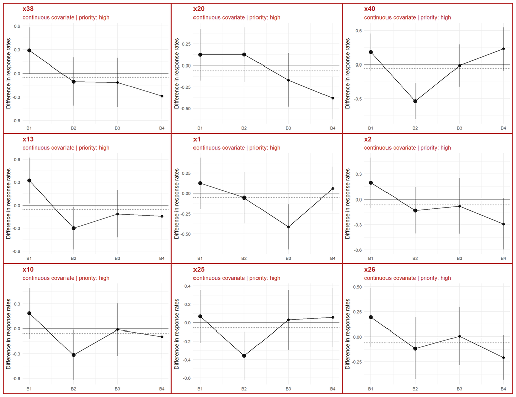

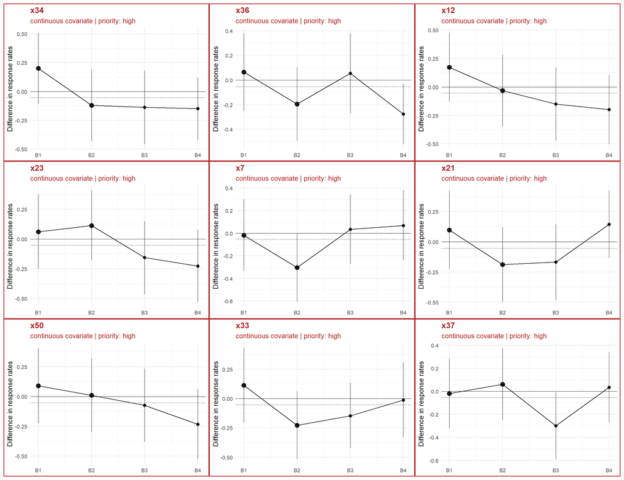

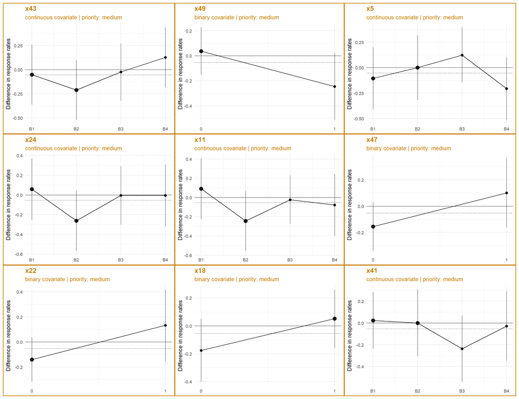

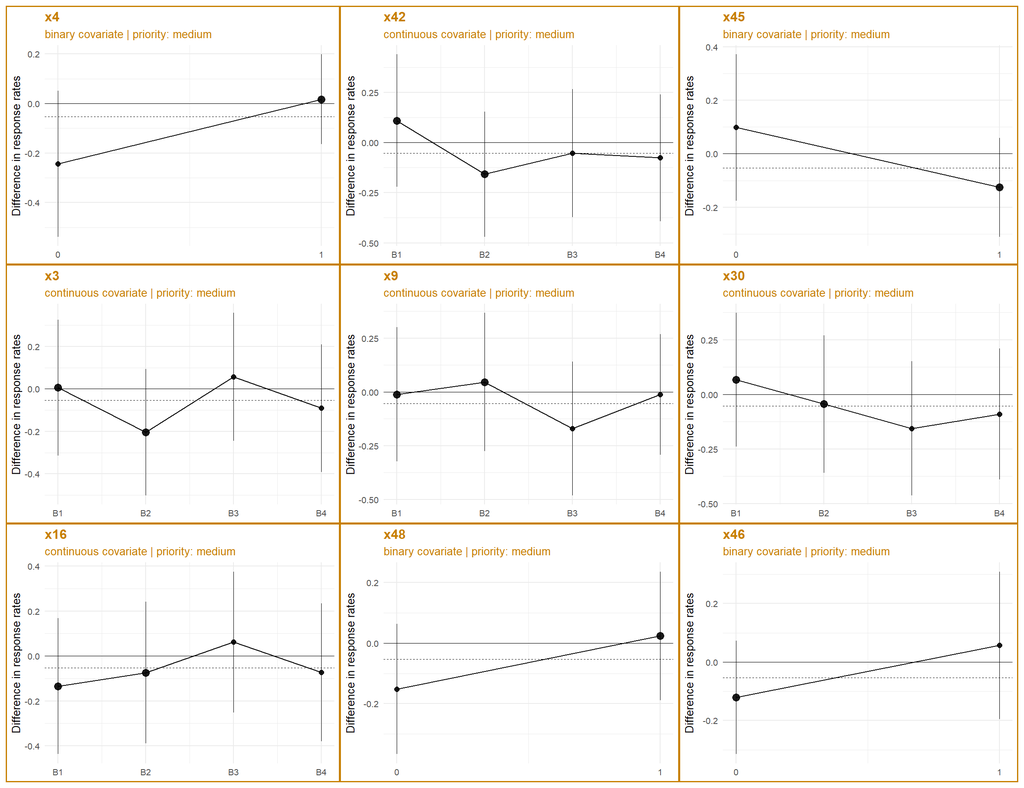

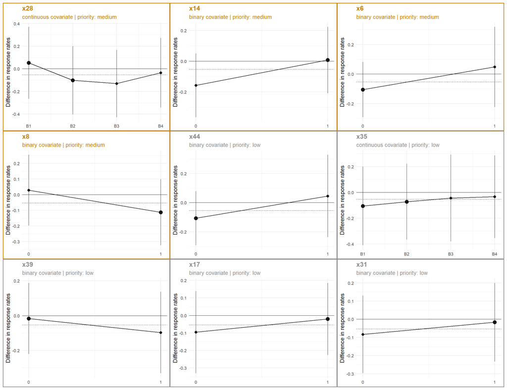

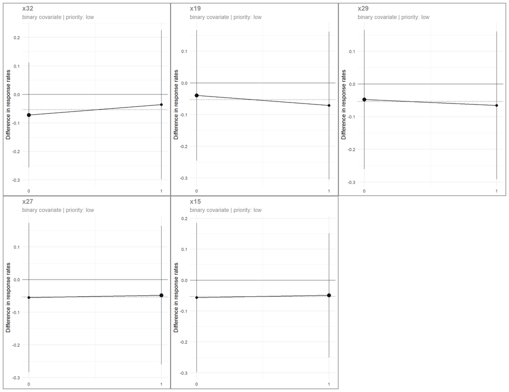

## Dataset 1652

All variables are shown. Numeric prioritisation is used only to order and colour the plots for faster visual review.

| dataset_id | endpoint | n_obs | n_vars | n_bins | overall_effect |
| --- | --- | --- | --- | --- | --- |
| 1652 | continuous | 150 | 15 | 4 | 2.529 |

### Dataset priority overview

| n_high | n_medium | n_low | prop_high | prop_medium_or_higher | max_priority_score | mean_priority_score | top_priority_vars | dataset_priority_hint |
| --- | --- | --- | --- | --- | --- | --- | --- | --- |
| 1 | 6 | 8 | 0.067 | 0.467 | 1.052 | 0.442 | x8, x11, x3, x9, x14 | high_plus_additional_support |

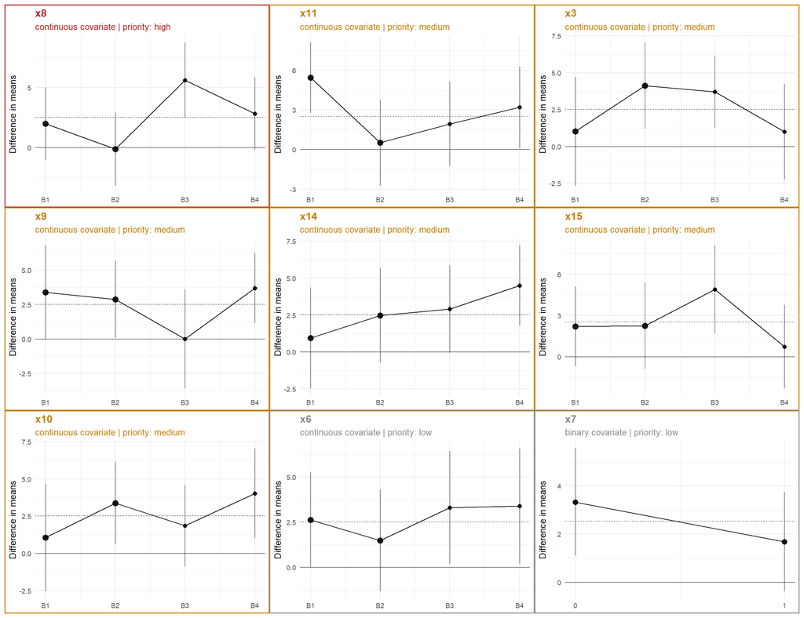

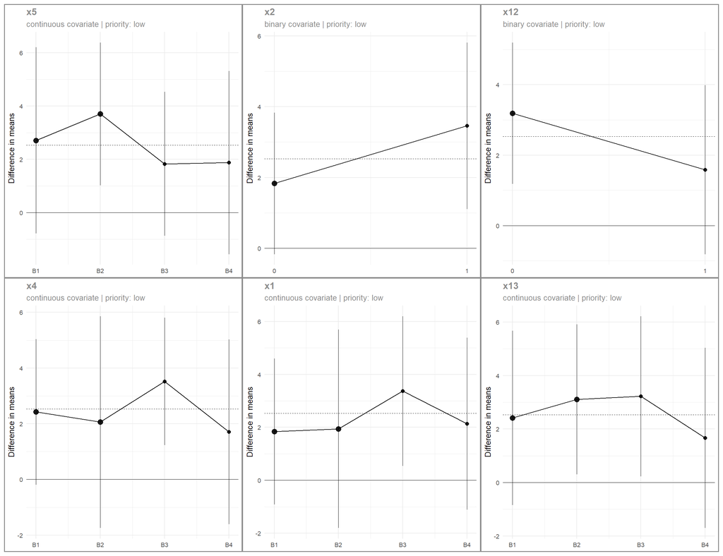

## Dataset 1964

All variables are shown. Numeric prioritisation is used only to order and colour the plots for faster visual review.

| dataset_id | endpoint | n_obs | n_vars | n_bins | overall_effect |
| --- | --- | --- | --- | --- | --- |
| 1964 | binary | 500 | 6 | 6 | 0.26 |

### Dataset priority overview

| n_high | n_medium | n_low | prop_high | prop_medium_or_higher | max_priority_score | mean_priority_score | top_priority_vars | dataset_priority_hint |
| --- | --- | --- | --- | --- | --- | --- | --- | --- |
| 1 | 2 | 3 | 0.167 | 0.5 | 0.85 | 0.425 | x3, x4, x1, x2, x6 | high_plus_additional_support |

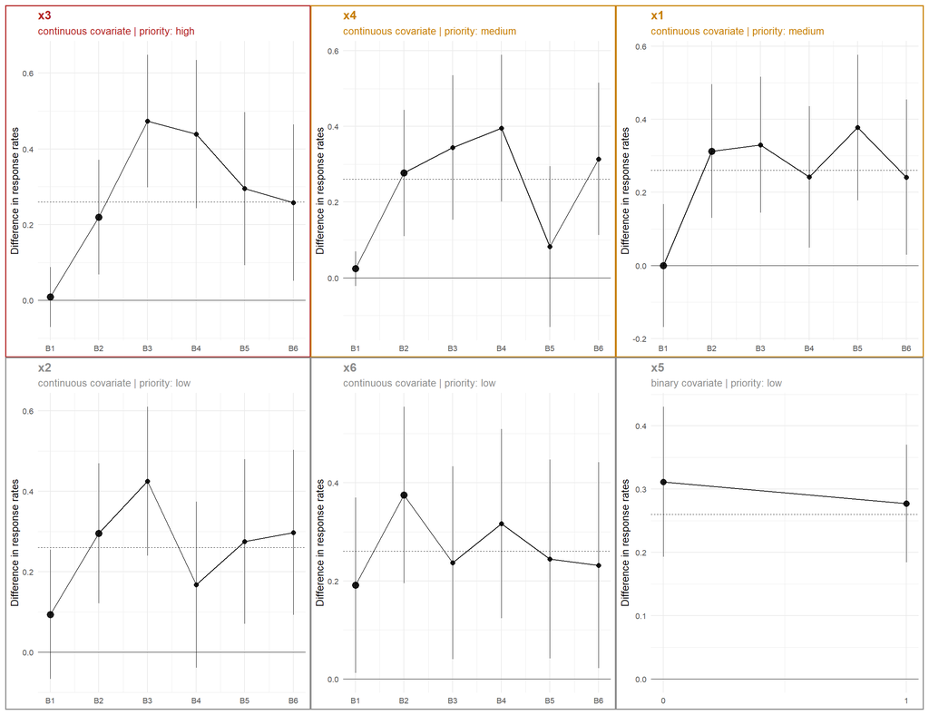

## Dataset 2119

All variables are shown. Numeric prioritisation is used only to order and colour the plots for faster visual review.

| dataset_id | endpoint | n_obs | n_vars | n_bins | overall_effect |
| --- | --- | --- | --- | --- | --- |
| 2119 | continuous | 700 | 6 | 8 | -0.014 |

### Dataset priority overview

| n_high | n_medium | n_low | prop_high | prop_medium_or_higher | max_priority_score | mean_priority_score | top_priority_vars | dataset_priority_hint |
| --- | --- | --- | --- | --- | --- | --- | --- | --- |
| 2 | 2 | 2 | 0.333 | 0.667 | 1.1 | 0.675 | x6, x4, x3, x1, x2 | high_plus_additional_support |

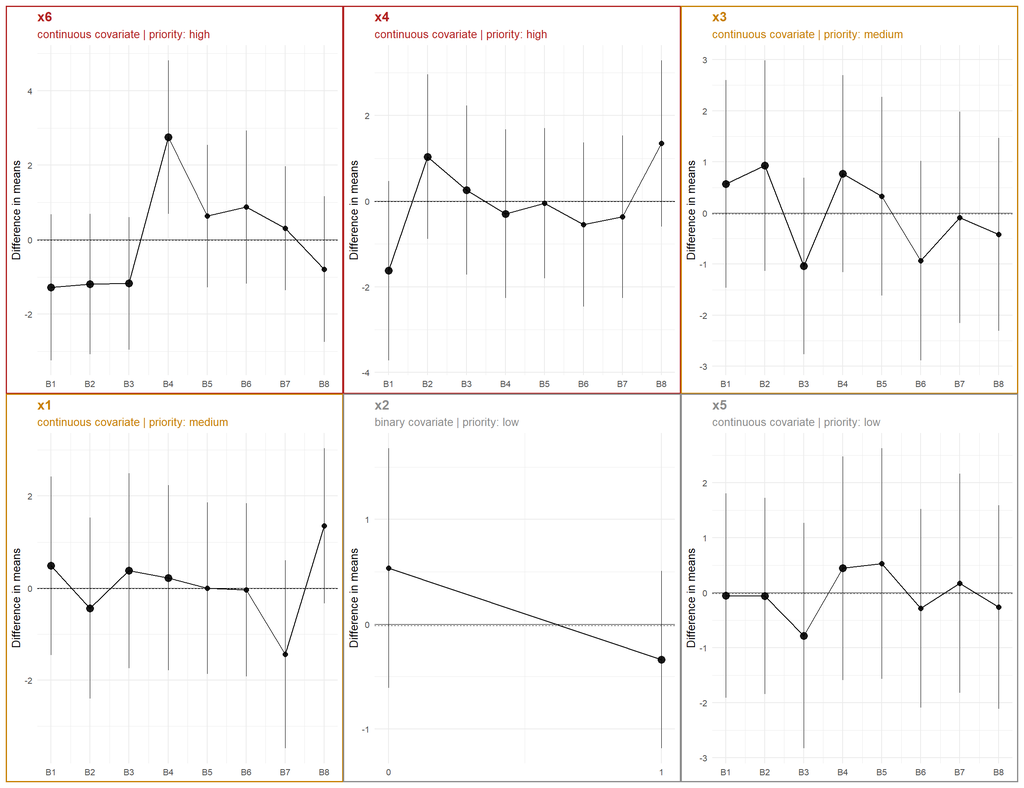

## Dataset 2318

All variables are shown. Numeric prioritisation is used only to order and colour the plots for faster visual review.

| dataset_id | endpoint | n_obs | n_vars | n_bins | overall_effect |
| --- | --- | --- | --- | --- | --- |
| 2318 | continuous | 700 | 50 | 8 | 2.211 |

### Dataset priority overview

| n_high | n_medium | n_low | prop_high | prop_medium_or_higher | max_priority_score | mean_priority_score | top_priority_vars | dataset_priority_hint |
| --- | --- | --- | --- | --- | --- | --- | --- | --- |
| 5 | 22 | 23 | 0.1 | 0.54 | 1.005 | 0.435 | x35, x41, x30, x28, x2 | multiple_high_priority_signals |

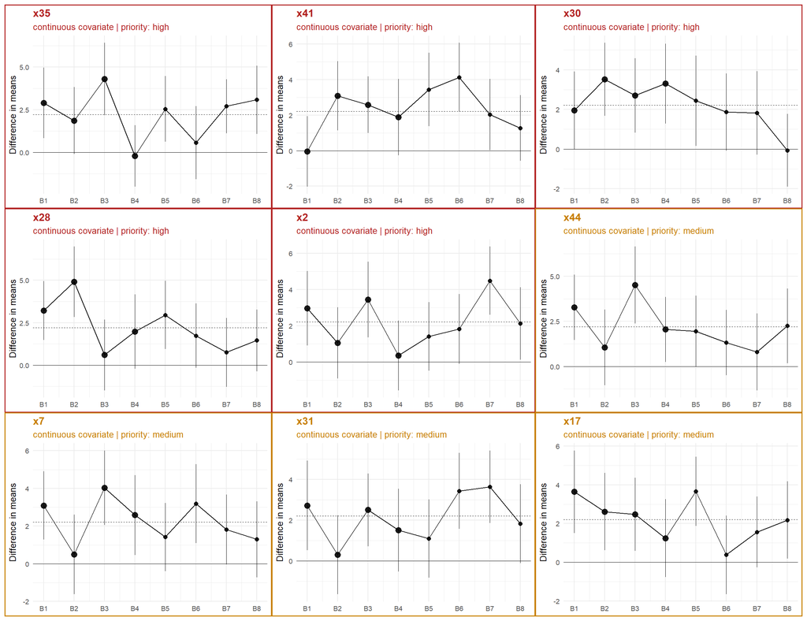

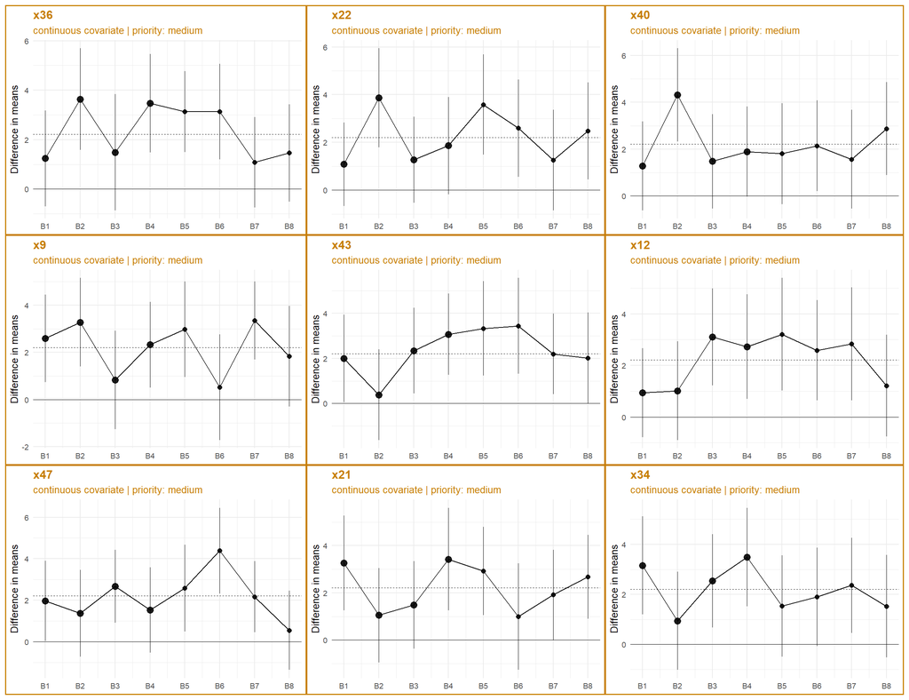

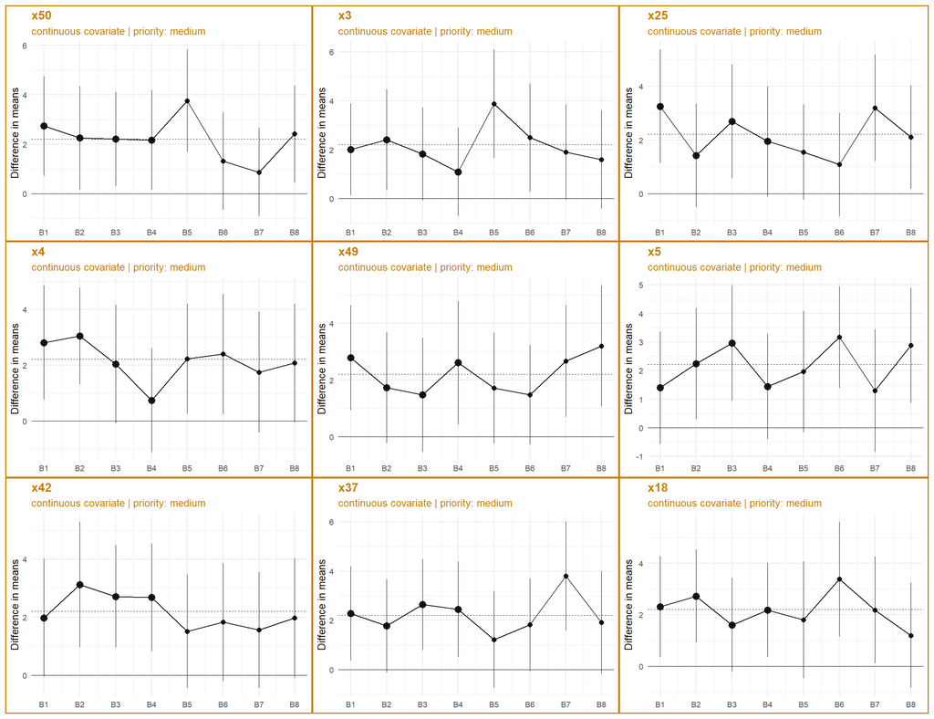

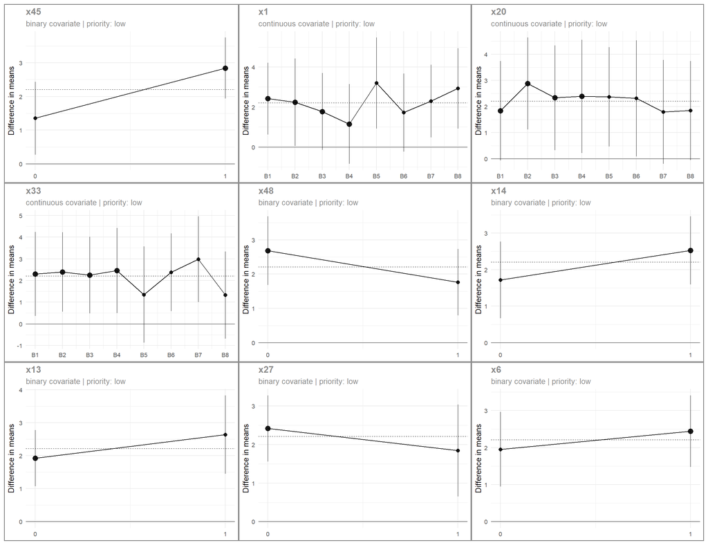

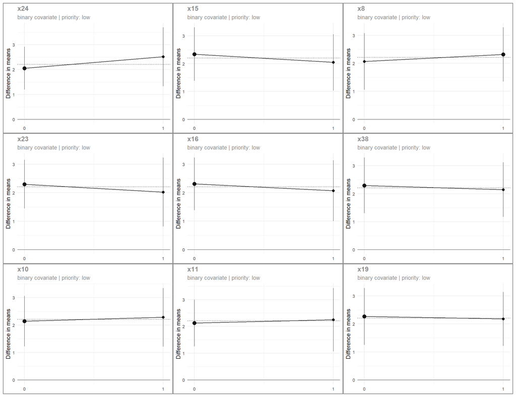

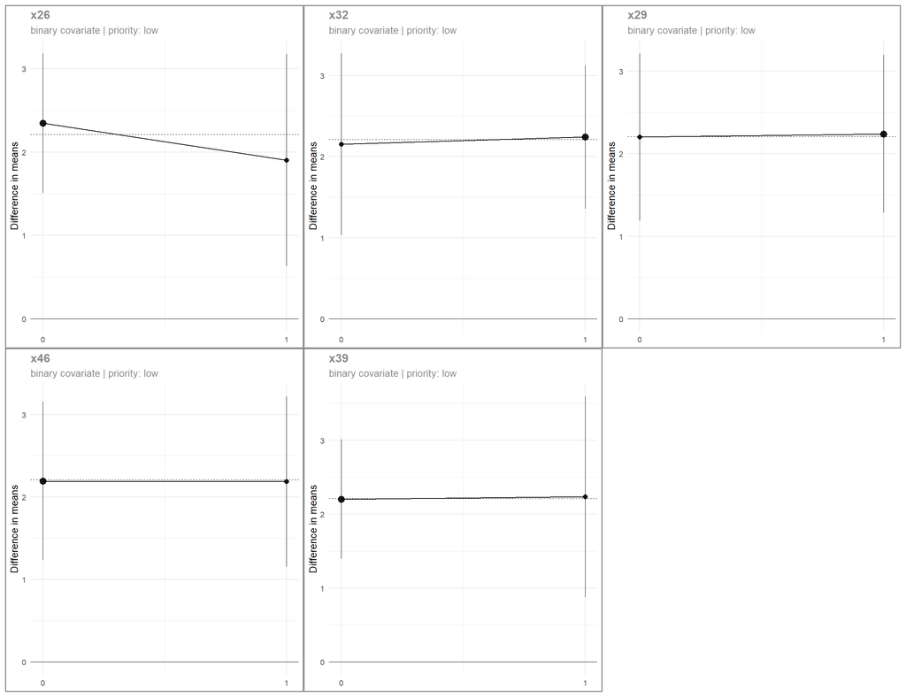

## Dataset 2771

All variables are shown. Numeric prioritisation is used only to order and colour the plots for faster visual review.

| dataset_id | endpoint | n_obs | n_vars | n_bins | overall_effect |
| --- | --- | --- | --- | --- | --- |
| 2771 | binary | 150 | 15 | 4 | 0 |

### Dataset priority overview

| n_high | n_medium | n_low | prop_high | prop_medium_or_higher | max_priority_score | mean_priority_score | top_priority_vars | dataset_priority_hint |
| --- | --- | --- | --- | --- | --- | --- | --- | --- |
| 5 | 8 | 2 | 0.333 | 0.867 | 1.036 | 0.675 | x10, x5, x7, x13, x2 | multiple_high_priority_signals |

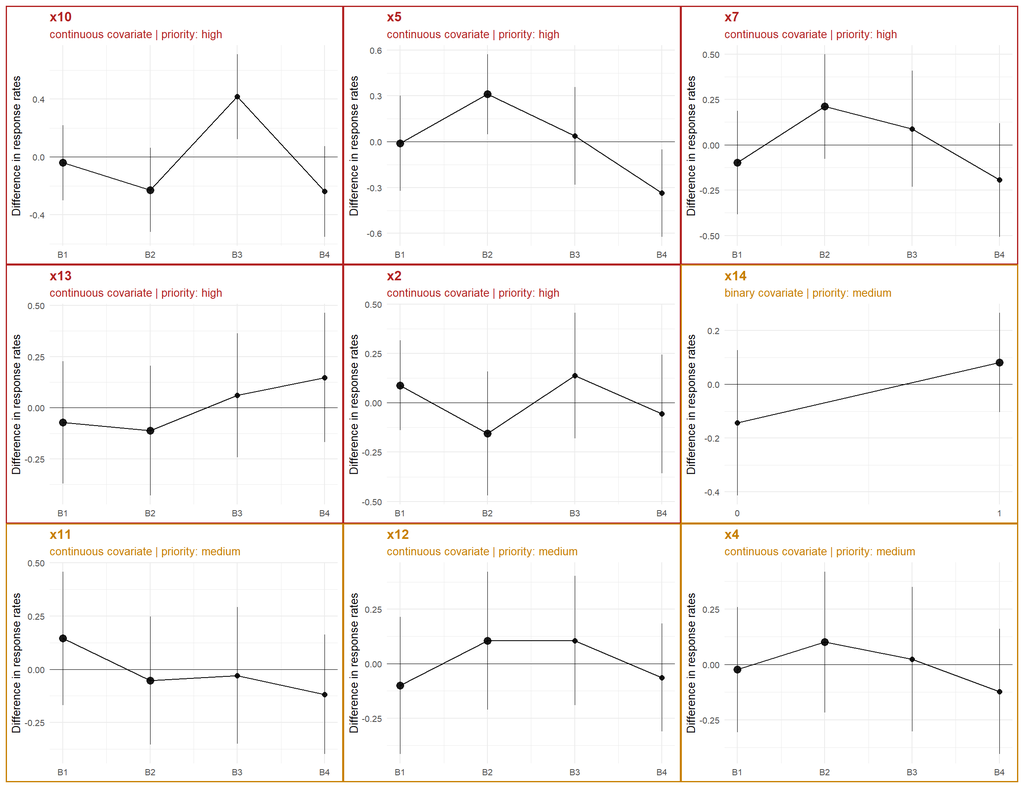

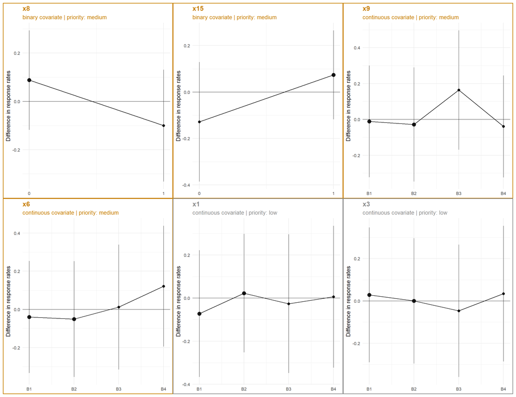

## Dataset 2941

All variables are shown. Numeric prioritisation is used only to order and colour the plots for faster visual review.

| dataset_id | endpoint | n_obs | n_vars | n_bins | overall_effect |
| --- | --- | --- | --- | --- | --- |
| 2941 | continuous | 150 | 6 | 4 | -0.442 |

### Dataset priority overview

| n_high | n_medium | n_low | prop_high | prop_medium_or_higher | max_priority_score | mean_priority_score | top_priority_vars | dataset_priority_hint |
| --- | --- | --- | --- | --- | --- | --- | --- | --- |
| 2 | 3 | 1 | 0.333 | 0.833 | 1.035 | 0.675 | x4, x5, x1, x2, x6 | high_plus_additional_support |

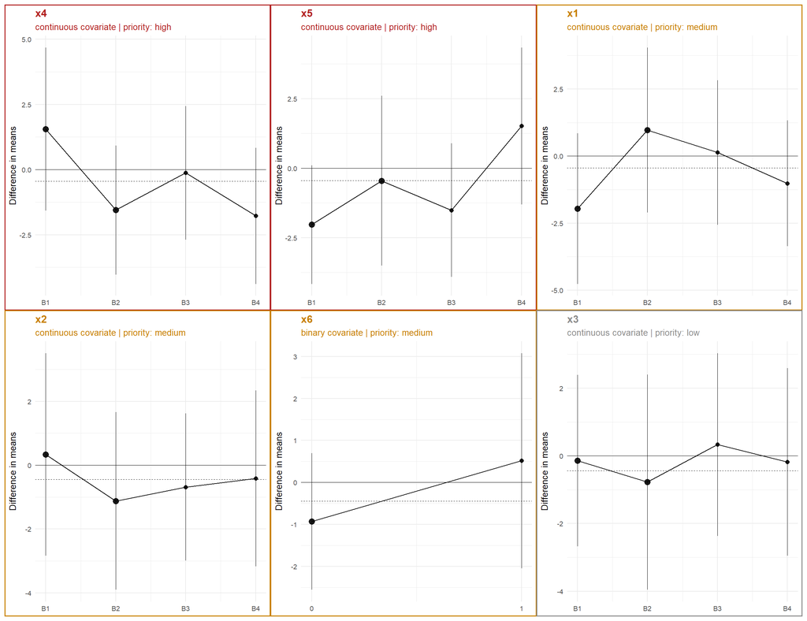

## Dataset 3354

All variables are shown. Numeric prioritisation is used only to order and colour the plots for faster visual review.

| dataset_id | endpoint | n_obs | n_vars | n_bins | overall_effect |
| --- | --- | --- | --- | --- | --- |
| 3354 | binary | 500 | 50 | 6 | 0.032 |

### Dataset priority overview

| n_high | n_medium | n_low | prop_high | prop_medium_or_higher | max_priority_score | mean_priority_score | top_priority_vars | dataset_priority_hint |
| --- | --- | --- | --- | --- | --- | --- | --- | --- |
| 21 | 13 | 16 | 0.42 | 0.68 | 1.068 | 0.585 | x13, x2, x6, x12, x21 | multiple_high_priority_signals |

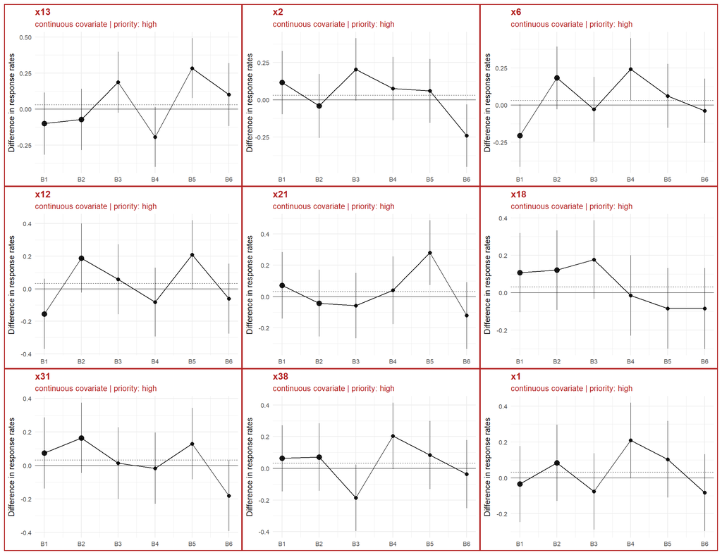

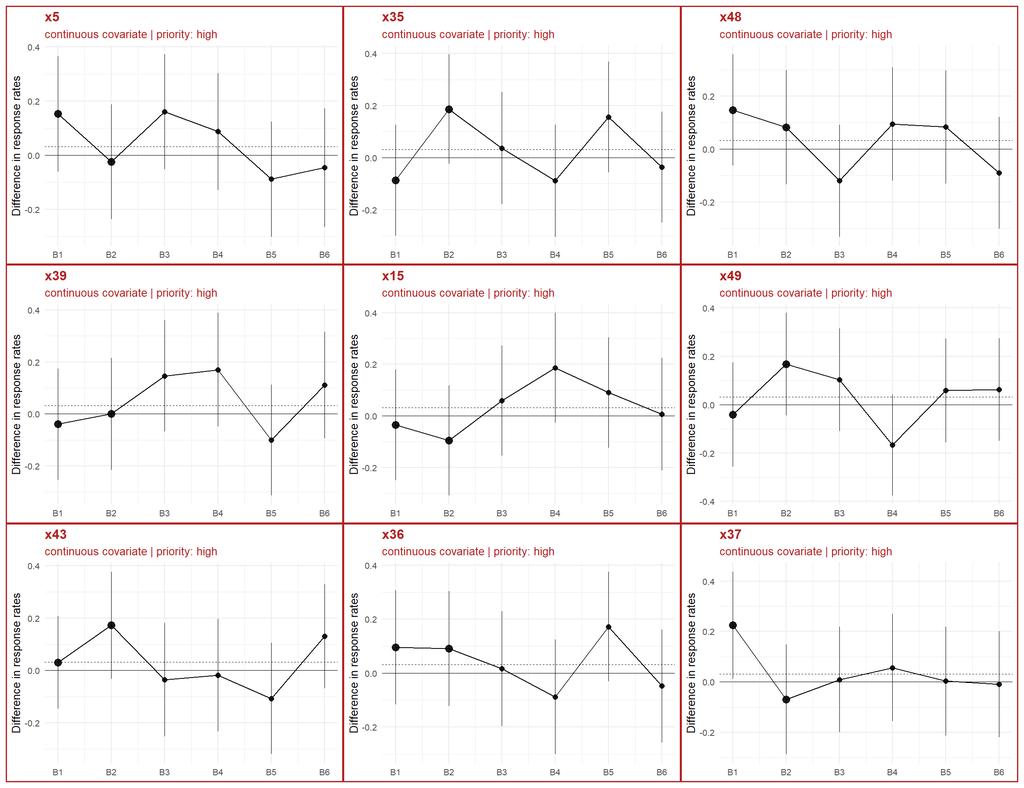

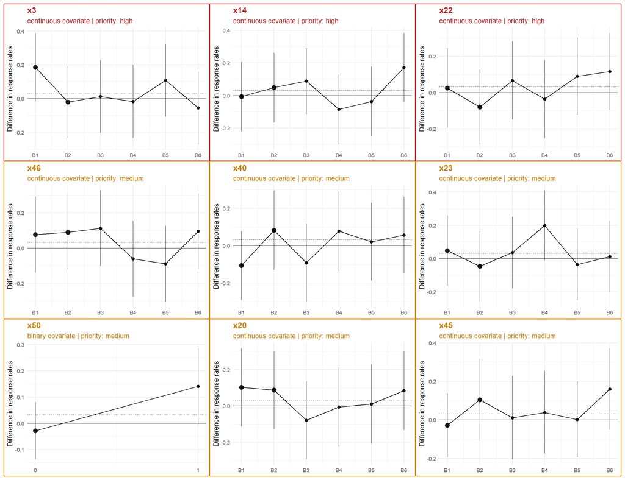

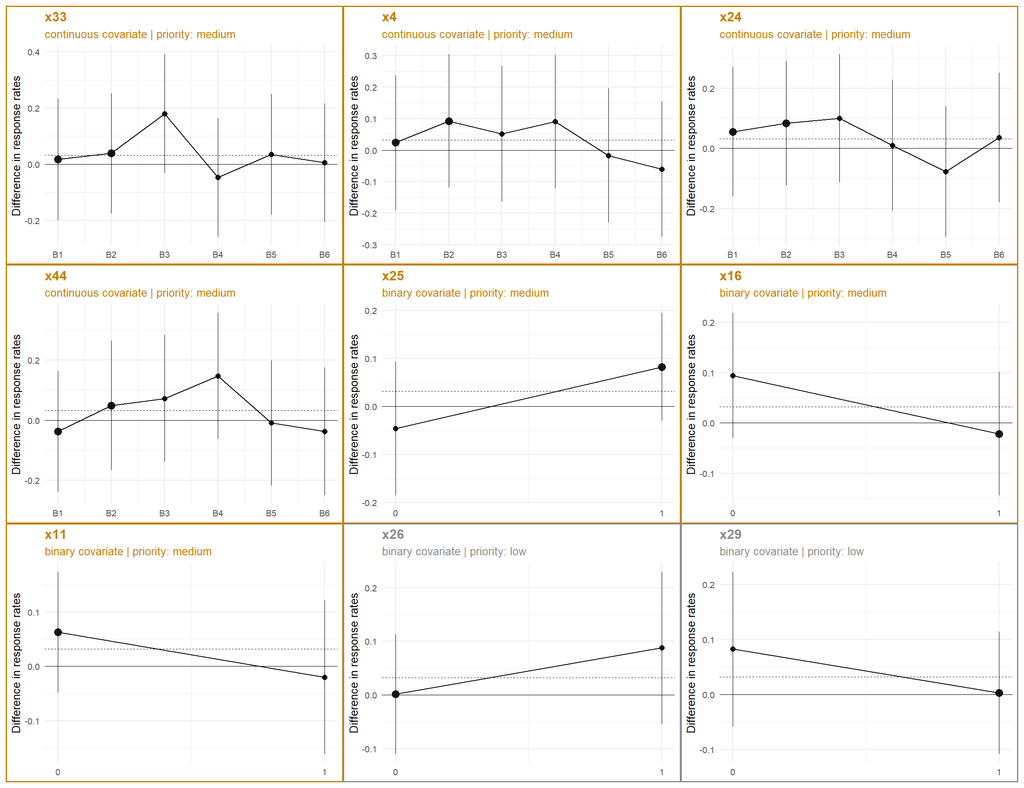

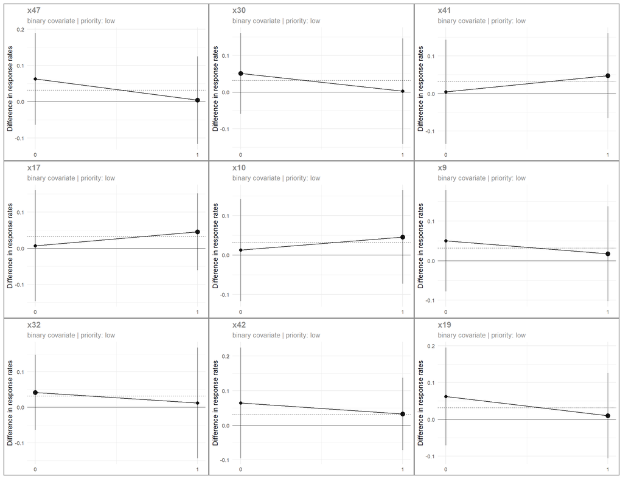

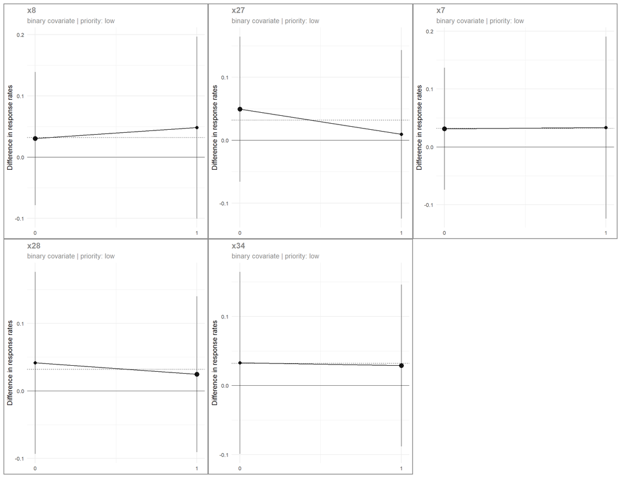

## Dataset 3453

All variables are shown. Numeric prioritisation is used only to order and colour the plots for faster visual review.

| dataset_id | endpoint | n_obs | n_vars | n_bins | overall_effect |
| --- | --- | --- | --- | --- | --- |
| 3453 | continuous | 150 | 50 | 4 | 1.487 |

### Dataset priority overview

| n_high | n_medium | n_low | prop_high | prop_medium_or_higher | max_priority_score | mean_priority_score | top_priority_vars | dataset_priority_hint |
| --- | --- | --- | --- | --- | --- | --- | --- | --- |
| 14 | 10 | 26 | 0.28 | 0.48 | 1.04 | 0.5 | x6, x34, x39, x14, x5 | multiple_high_priority_signals |

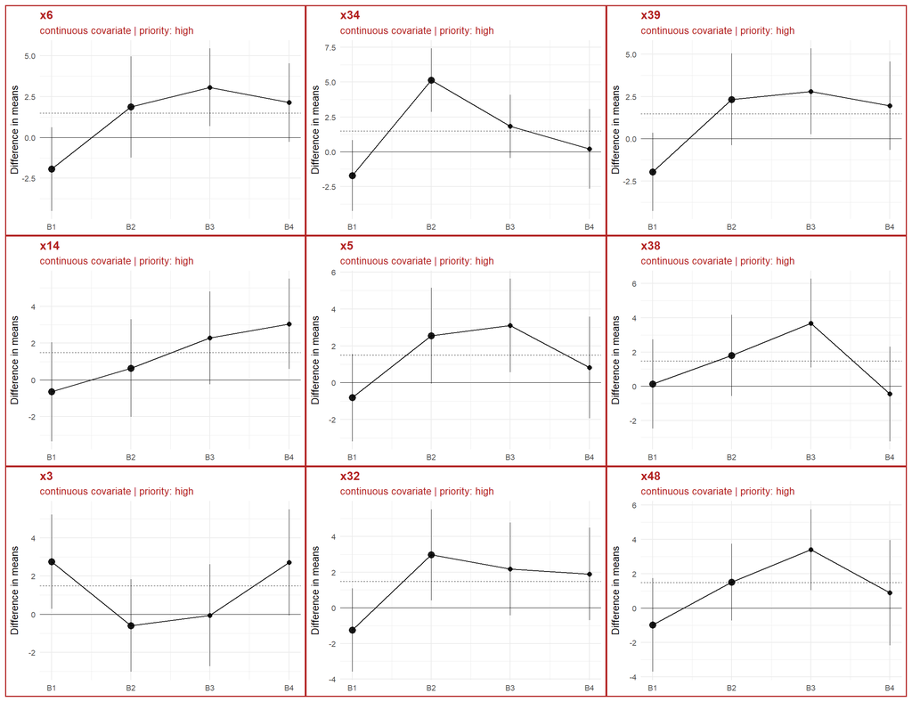

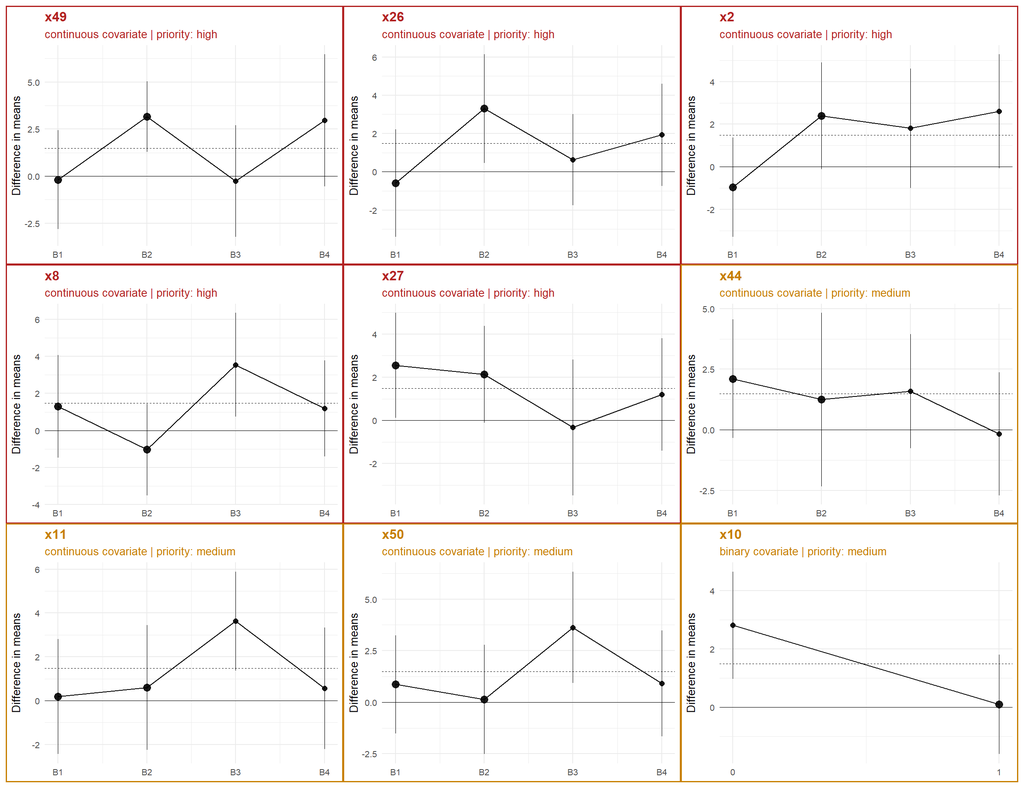

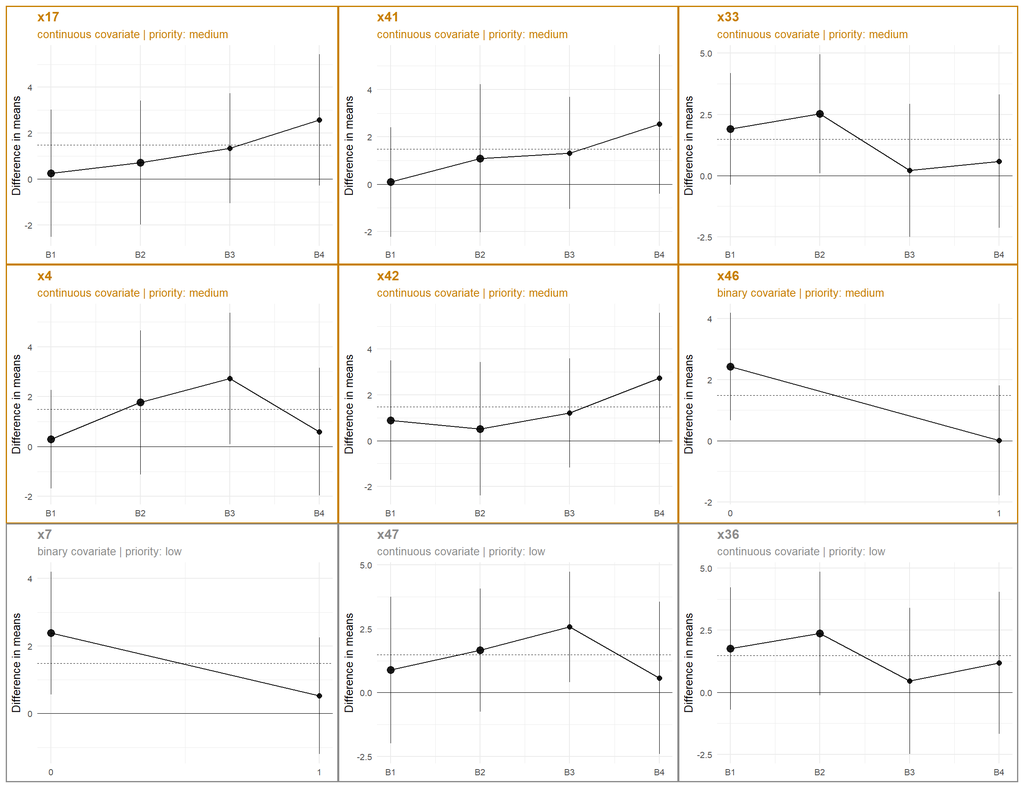

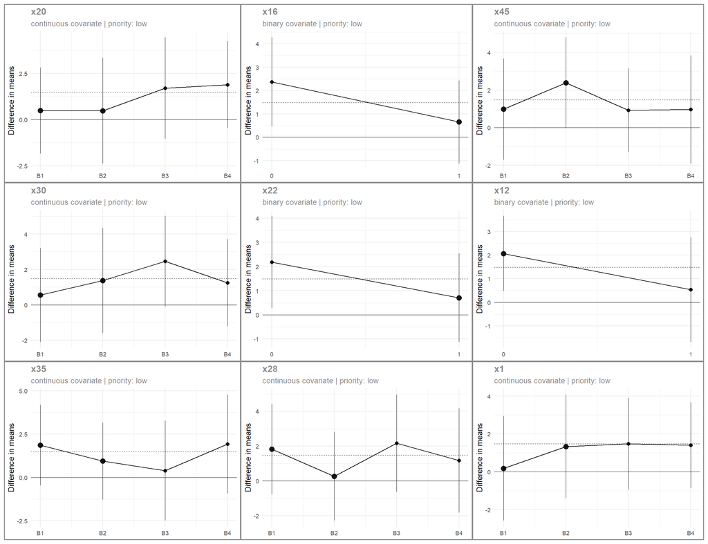

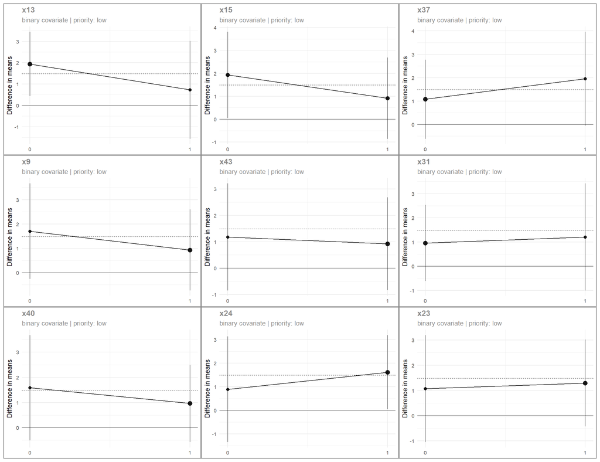

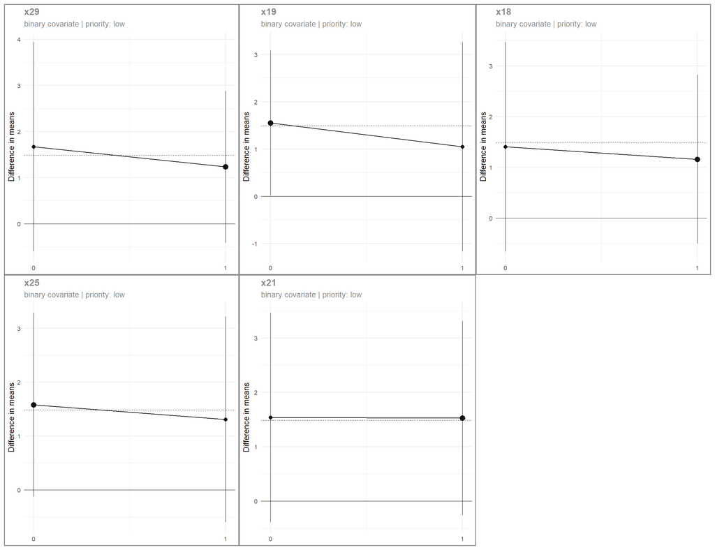

## Dataset 3608

All variables are shown. Numeric prioritisation is used only to order and colour the plots for faster visual review.

| dataset_id | endpoint | n_obs | n_vars | n_bins | overall_effect |
| --- | --- | --- | --- | --- | --- |
| 3608 | continuous | 150 | 6 | 4 | -1.254 |

### Dataset priority overview

[output not shown]

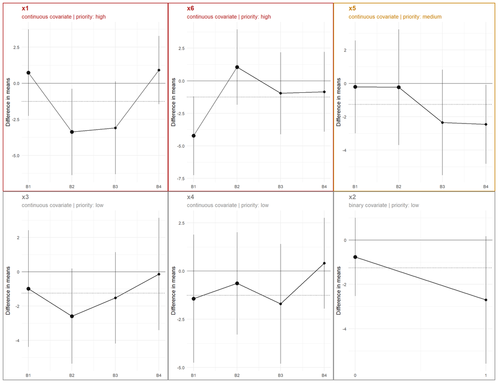

## Dataset 3694

All variables are shown. Numeric prioritisation is used only to order and colour the plots for faster visual review.

| dataset_id | endpoint | n_obs | n_vars | n_bins | overall_effect |
| --- | --- | --- | --- | --- | --- |
| 3694 | continuous | 700 | 15 | 8 | 1.883 |